# Exposure and Infection

Modeling the *Pf*EIR and the *Pf*PR

December 15, 2023

`~/Malaria Epidemiology/Exposure-and-Infection.Rmd`

HUB – Roadmap – Library – Malaria Epidemiology – Exposure – Progressive Estimation

This document is being done in the service of a *manuscript* on  
Scaling Relationships –

## $\odot$

A core problem for malaria epidemiology is the relationship between exposure (*i.e.*, as defined by the entomological inoculation rate or EIR) and infection (*i.e.* as defined by the prevalence of infection or PR). In the following document, we introduce a flexible mathematical framework for modeling exposure and infection, and we explore several factors affecting the scaling relationship. In this document, we use the cohort utilities in `exDE` to illustrate several factors that modify the scaling relationship between the EIR and the PR. In this document, we are taking an abstract, conceptual approach.

For RAMP, the big picture also involves an inferential process (see **Fig. 1**). In this document, we have not dealt with with either age or the observational process (*i.e.* sampling). We cover those topics more thoroughly in a synthesis of Scaling. Here, we deal with:

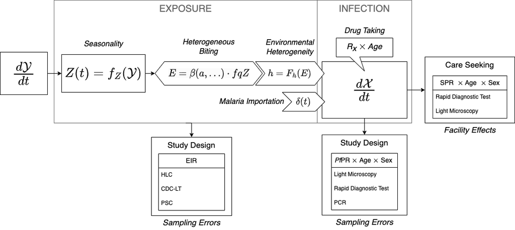

**Figure 1**: A core problem is to understand the intensity of malaria transmission by mosquitoes, which requires understanding the process of exposure and infection. This diagram illustrates how the RAMP algorithms deal with the relationship.

## EIR-PR

### $\oplus$

**Exposure**

- *Exposure risk* is defined herein as time spent at a place and time when infective mosquitoes are biting.
- *Exposure rates* are defined as the expected number of infective bites, per person, per day, or the *daily entomological inoculation rate* (dEIR).

**Infection**

- The true prevalence of *infection* is the fraction of people who are infected with parasites. For historical reasons, we call this the **parasite rate** (PR).
- The apparent PR is the fraction who are found to be infected by light microscopy (LM), by rapid diagnostic test (RDT), or by PCR.
- The true and apparent PR vary with respect to **age**
  - Humans are born uninfected, so the PR rises with age.
  - Exposure to malaria tends to vary by age.
  - Immunity is acquired with age and exposure, reducing parasite densities and detection.
  - Drug taking probably varies with age.
- The true and apparent PR vary with respect to **sex**

**Scaling**

We start with the simplest model in malaria, called the **SIS** compartment model. The relationship between the EIR and the PR is modified by several factors, including:

### SIS

Here, we look at Ross’s model:

$$\frac{dX}{dt} = bE(H-X) - rX$$
In the following, we plot with values of $r \in \left\{1/100, 1/180, 1/220\right\}.$

```r
F_eir0 = function(t, pars){0*t+1}
F_eir1 = function(t, pars){(1.05 + sin(2*pi*t/365))}
F_eir2 = function(t, pars){(1.05 + sin(2*pi*t/365))^3}
```

```r
sis = xde_setup_cohort("sis", F_eir0, Xname = "SIS")
xde_scaling_eir(sis, 25) -> sis
sis0 <- sis
sis0$Xpar$r <- 1/100
xde_scaling_eir(sis0, 25) -> sis0
sis1 <- sis
sis1$Xpar$r <- 1/220
xde_scaling_eir(sis1, 25) -> sis1
```

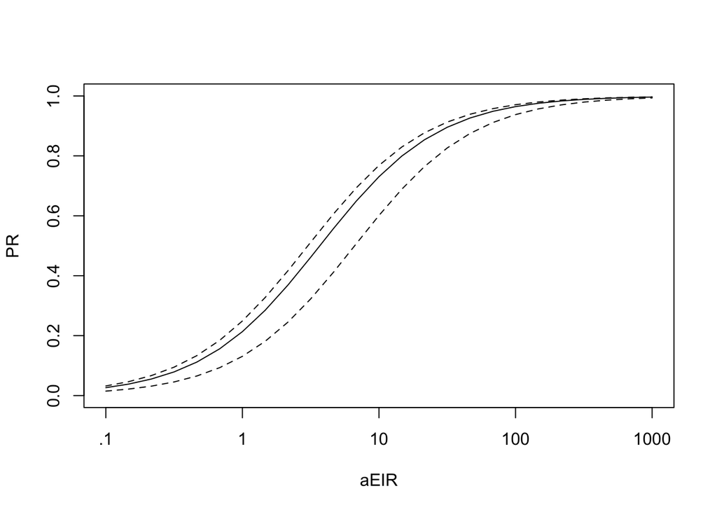

```r
plot_eirpr(sis)
lines_eirpr(sis0, llty=2)
lines_eirpr(sis1, llty=2)
```

### Drug Taking

Drug taking is handled differently in every model ($\cal X$). Here, we explore the relationship with the model SIP.

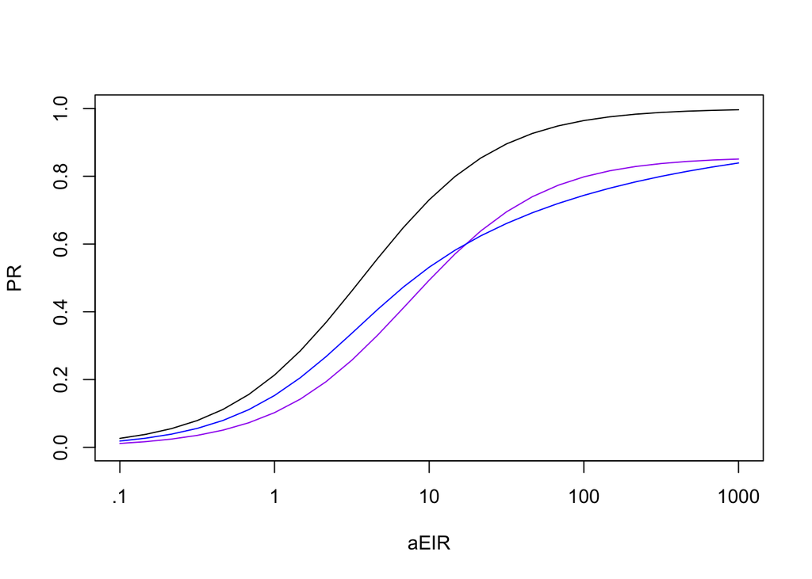

```r
plot_eirpr(sis)
lines_eirpr(sip, "purple")
lines_eirpr(sip1, "blue")
```

### Heterogeneity

#### Environmental Heterogeneity

**Environmental Heterogeneity** is handled through a function that converts the EIR into the FoI, $h=F_h(E)$. As part of that function, mean biting can have a distribution which we incorporate through a function, $F_h$ that captures **environmental heterogeneity.** Each model, $d {\cal X}/ dt$, must supply a function to compute the probability of infection per infectious bite.

```r
sis2 <- setup_exposure_nb(sis, 1/50)
sis3 <- setup_exposure_nb(sis, 1/100)
xde_scaling_eir(sis2, 25) -> sis2
xde_scaling_eir(sis3, 25) -> sis3
```

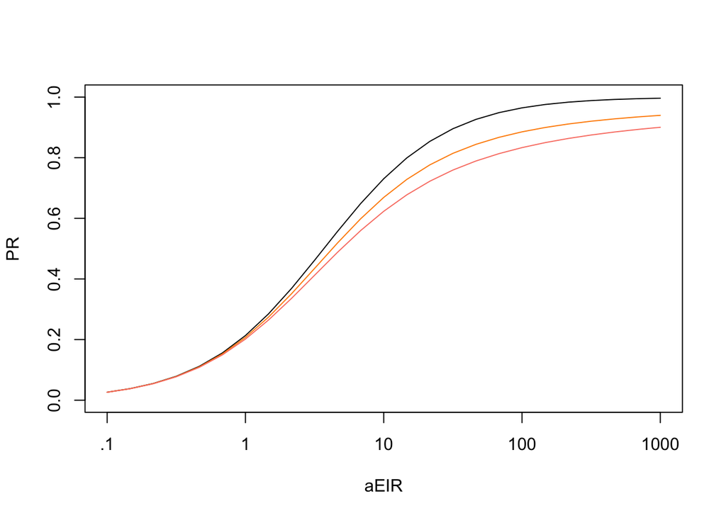

```r
plot_eirpr(sis)
lines_eirpr(sis2, "darkorange")
lines_eirpr(sis3, "salmon")
```

#### Frailties

```r
sis3 = split_stratum_by_biting(sis, 1, .2, sqrt(10))
xde_scaling_eir(sis3, 25) -> sis3
```

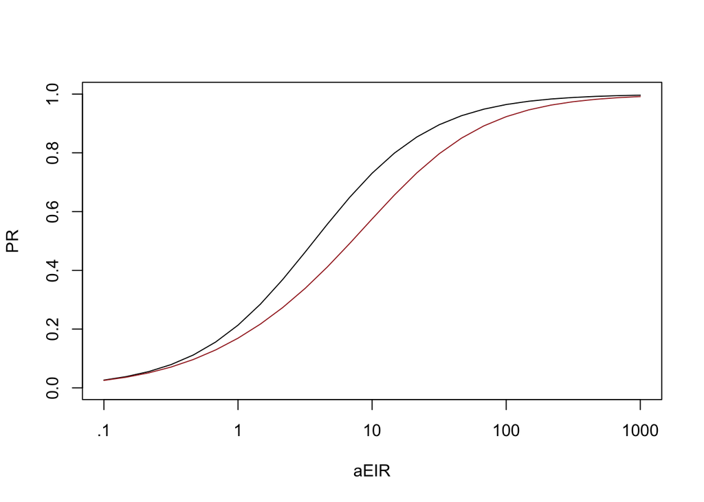

```r
plot_eirpr(sis)
lines_eirpr(sis3, "brown")
```

### Travel

We can sometimes overestimate *local* mosquito populations if there is exposure elsewhere. Some of this is handled through mobility in the **TaR** matrix and incorporated into $\beta$. Malaria acquired through travel, $\delta(t)$, is handled separately [1].

```r
sis4 <- setup_travel_foi(sis, delta_scale = 1/5/365)
xde_scaling_eir(sis4, 25) -> sis4
```

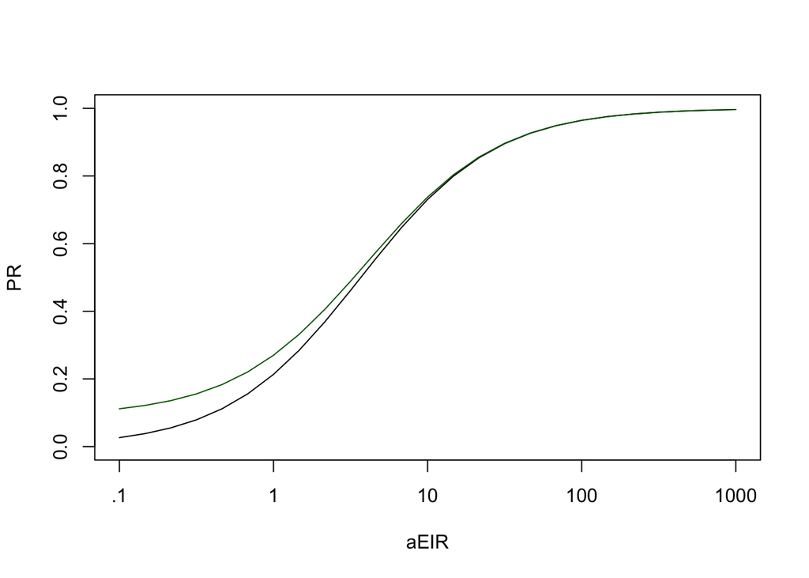

```r
plot_eirpr(sis)
lines_eirpr(sis4, "darkgreen")
```

### Seasonality

An overview of heterogeneous exposure is covered in Exposure, which includes heterogeneous biting and environmental exposure.

```r
sis6 = sis
sis7 = sis
sis6$F_eir = F_eir1
sis7$F_eir = F_eir2
xde_scaling_eir(sis6, 25) -> sis6
xde_scaling_eir(sis7, 25) -> sis7
```

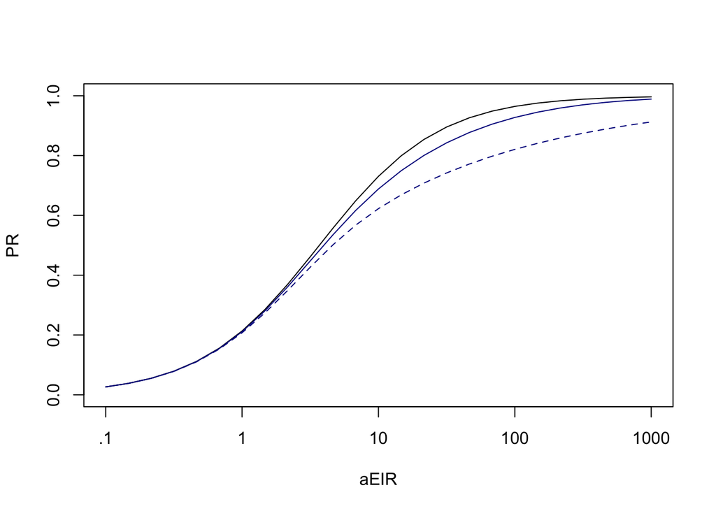

```r
plot_eirpr(sis)
lines_eirpr(sis6, "darkblue")
lines_eirpr(sis7, "darkblue", 2)
```

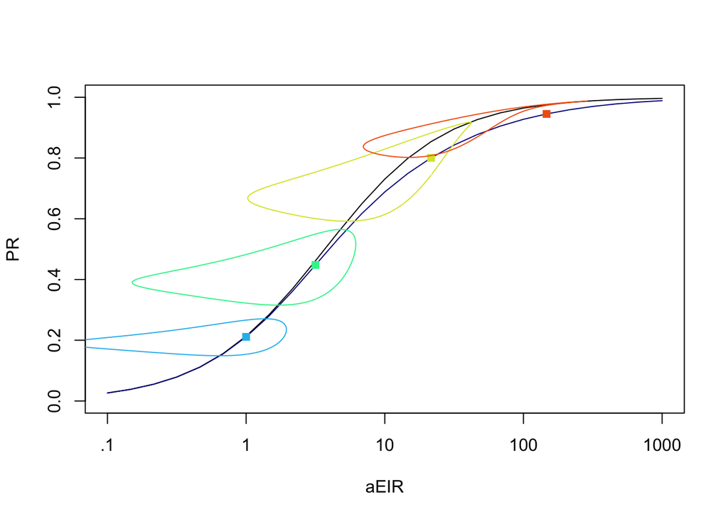

```r
plot_eirpr(sis)
lines_eirpr(sis6, "darkblue")
require(viridis)
clrs = turbo(25)
with(sis6$outputs$eirpr,{
  points(aeir[c(7,10,15,20)], pr[c(7,10,15,20)], col = clrs[c(7,10,15,20)], pch=15)
  lines(scaling[[7]]$aeir, scaling[[7]]$pr, col = clrs[7])
  lines(scaling[[10]]$aeir, scaling[[10]]$pr, col = clrs[10])
  lines(scaling[[15]]$aeir, scaling[[15]]$pr, col = clrs[15])
  lines(scaling[[20]]$aeir, scaling[[20]]$pr, col = clrs[20])
})
```

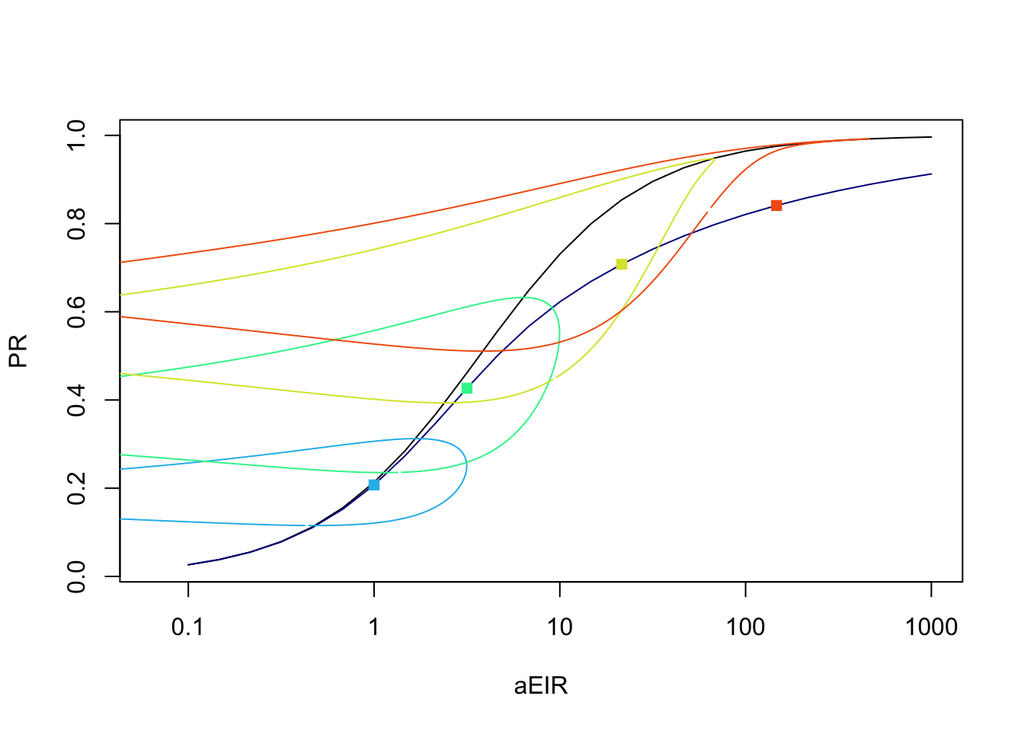

```r
with(sis$outputs$eirpr, plot(aeir, pr, type = "l", log = "x", xaxt= "n", xlab = "aEIR", ylab = "PR", xlim = 10^c(-1.2,3)))
axis(1, 10^(-1:3), c(0.1, 1, 10, 100, 1000))
with(sis7$outputs$eirpr, lines(aeir, pr, col = "darkblue"))
clrs = turbo(25)
with(sis7$outputs$eirpr, {
  points(aeir[c(7,10,15,20)], pr[c(7,10,15,20)], col = clrs[c(7,10,15,20)], pch=15)
  lines(scaling[[7]]$aeir,  scaling[[7]]$pr, col = clrs[7])
  lines(scaling[[10]]$aeir, scaling[[10]]$pr, col = clrs[10])
  lines(scaling[[15]]$aeir, scaling[[15]]$pr, col = clrs[15])
  lines(scaling[[20]]$aeir, scaling[[20]]$pr, col = clrs[20])
})
```

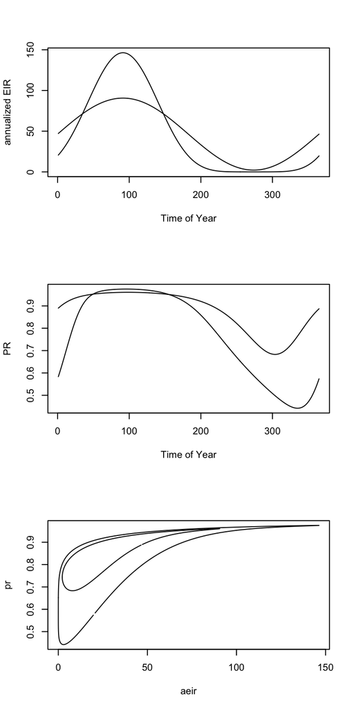

```r
par(mfrow = c(3,1))
with(sis7$outputs$eirpr$scaling[[17]], plot(1:365, aeir, type = "l", xlab="Time of Year", ylab = "annualized EIR"))
with(sis6$outputs$eirpr$scaling[[17]], lines(1:365, aeir))
with(sis7$outputs$eirpr$scaling[[17]], plot(1:365, pr, type = "l", xlab = "Time of Year", ylab = "PR"))
with(sis6$outputs$eirpr$scaling[[17]], lines(1:365, pr))
with(sis7$outputs$eirpr$scaling[[17]], plot(aeir, pr, type = "l"))
with(sis6$outputs$eirpr$scaling[[17]], lines(aeir, pr))
```

### Everything

```r
sipH <- xde_setup_cohort("sip", F_eir2, "SIP")
sipH <- setup_exposure_nb(sipH, 1/50)
sipH$Xpar$rho <- 0.2
sipH$Xpar$xi <- 2/365
sipH <- setup_travel_foi(sipH, delta_scale = 2/5/365)
sipH <- xde_scaling_eir(sipH, 25)
```

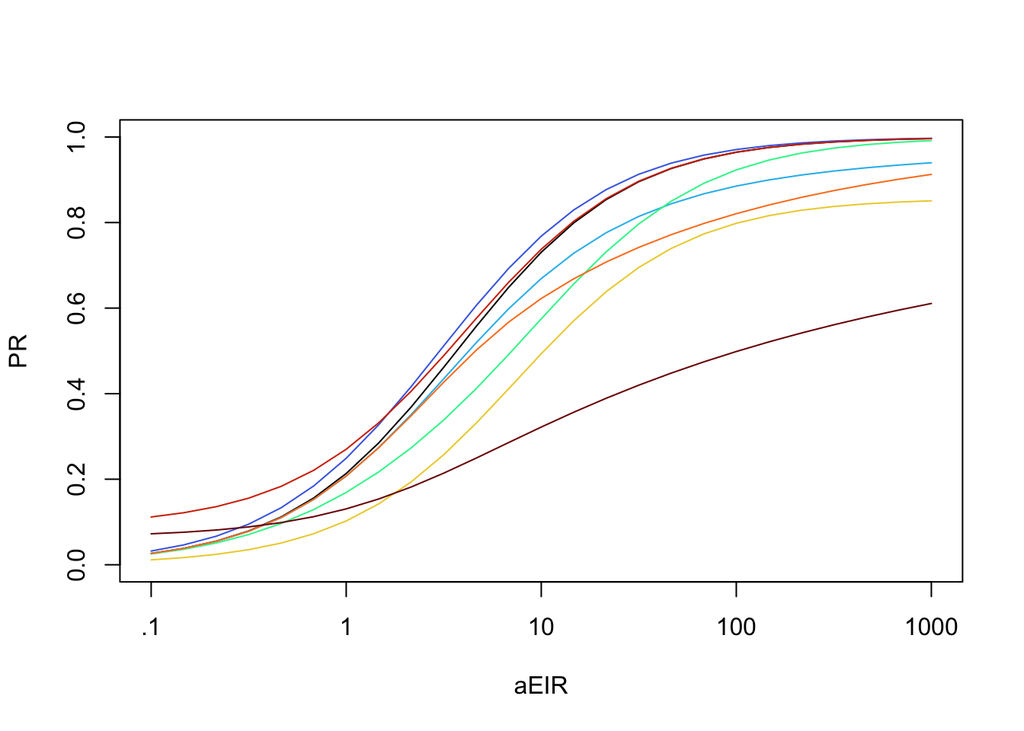

```r
clrs = turbo(9)
plot_eirpr(sis)
lines_eirpr(sis1, clrs[2])
lines_eirpr(sis2, clrs[3])
lines_eirpr(sis3, clrs[4])
lines_eirpr(sis4, clrs[8])
lines_eirpr(sip, clrs[6])
lines_eirpr(sis7, clrs[7])
lines_eirpr(sipH, clrs[9])
```

## Summary

This figure summarizes the basic concepts:

1. There is process uncertainty.
2. The relationship is modified by drug taking, heterogeneous exposure, seasonality and travel.
3. When these effects are combined, the effect size can be quite large.

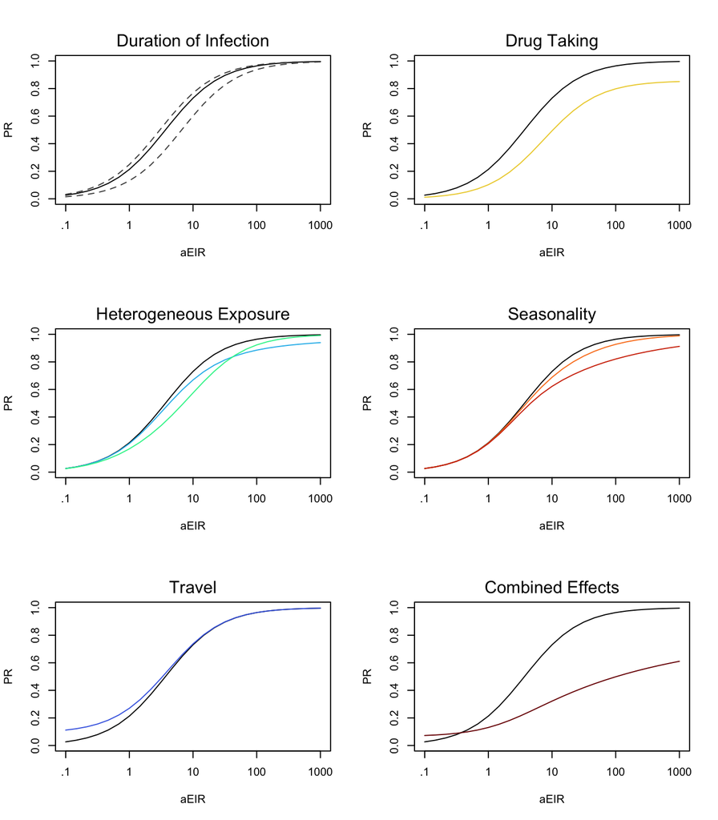

## Chron.Ann.Bib

Some important papers that got us here:

### Caveats

1. One source of heterogeneity in the relationship between the EIR and either the FOI or the PR is human mobility. The EIR *measured* here does not reflect the average level of exposure *experienced by* people living here. In some cases, travel can play an outsized role [Guerra, C. A. et al. Human mobility patterns and malaria importation on Bioko Island. Nat. Commun. 10, 2332 (2019)]. Here, we model the relationship between the *local* EIR and the PR.
2. Estimates of the EIR vary by method before [Kilama, M. et al. Estimating the annual entomological inoculation rate for Plasmodium falciparum transmitted by Anopheles gambiae s.l. using three sampling methods in three sites in Uganda. Malar. J. 13, 111 (2014)] and after control.[Musiime, A. K. et al. Impact of vector control interventions on malaria transmission intensity, outdoor vector biting rates and Anopheles mosquito species composition in Tororo, Uganda. Malar. J. 18, 445 (2019)]
3. Potential biases in the EIR estimates because of poor study designs.
4. Problems with counting zero sporozoite positive mosquitoes.

### Data and Benchmarking

#### Duration of an untreated infection without further exposure

- In 1950 [Macdonald, G. The analysis of malaria parasite rates in infants. Trop. Dis. Bull. 47, 915–938 (1950)], Macdonald used data from a paper by Earle, *et al.* describing pararasitemia in a cohort of untreated children [Earle, W. C., Pérez, M., del Río, J. & Arzola, C. Observations on the Course of Naturally Acquired Malaria in Puerto Rico. PR J. Public Health Trop. Med. 14, 391–406 (1939)]. The data, replotted by Macdonald as Figure 1 and Table 1, come from Table 3 of Earle. In 1962, Earle provided the data in more granular form [Earle, W. C. The course of naturally acquired malaria. WHO/Mal/333 (Feb 7, 1962) https://apps.who.int/iris/bitstream/handle/10665/64925/WHO_Mal_333.pdf]. Macdonald fit the curve to data. He found that after the first 31 days in which no one lost any infection, an exponential curve fit the data reasonably well with a decay rate of $0.0048$, or an average of aboug 208 days. Having reread Earle’s paper, it’s not at all clear that new infections were not occurring.
- The malariatherapy data.
- In 1964, Macdonald and Goekel summarized data describing declines in the PR after interventions.
- Nankabirwa, J. I. et al. Persistent Parasitemia Despite Dramatic Reduction in Malaria Incidence After 3 Rounds of Indoor Residual Spraying in Tororo, Uganda. J. Infect. Dis. 219, 1104–1111 (2019)
- Bekessy, A., Molineaux, L. & Storey, J. Estimation of incidence and recovery rates of Plasmodium falciparum parasitaemia from longitudinal data. Bull. World Health Organ. 54, 685–693 (1976)

#### Cross-sectional EIR vs. PR

#### Disease and Anti-malarial Drugs

- Rodriguez-Barraquer, I. et al. Quantification of anti-parasite and anti-disease immunity to malaria as a function of age and exposure. Elife 7, e35832 (2018)
- This paper shows a rise in the attack rates with age, extreme heterogeneity in monthly attack rates (which were starkly different for rural and urban populations), and a nearly linear decline in the risk of malaria given infection.[Rodriguez-Barraquer, I. et al. Quantifying heterogeneous malaria exposure and clinical protection in a cohort of Ugandan children. J. Infect. Dis. 214, 1072–1080 (2016)]

## $\boxplus$

- Lecture Notes
- EIR-PR

## $\dagger$

**Contributors**

- David L Smith

**References**

1.

Guerra CA, Kang SY, Citron DT, Hergott DEB, Perry M, Smith J, et al. Human mobility patterns and malaria importation on Bioko Island. Nat Commun. 2019;10: 2332. doi:10.1038/s41467-019-10339-1

2.

Kang SY, Battle KE, Gibson HS, Cooper LV, Maxwell K, Kamya M, et al. Heterogeneous exposure and hotspots for malaria vectors at three study sites in Uganda. Gates Open Res. 2018;2: 32. doi:10.12688/gatesopenres.12838.2

3.

Cooper L, Kang SY, Bisanzio D, Maxwell K, Rodriguez-Barraquer I, Greenhouse B, et al. Pareto rules for malaria super-spreaders and super-spreading. Nat Commun. 2019;10: 3939. doi:10.1038/s41467-019-11861-y

4.

Davey TH, Gordon RM. The estimation of the density of infective anophelines as a method of calculating the relative risk of inoculation with malaria from different species or in different localities. Ann Trop Med Parasitol. 1933;27: 27–52. doi:10.1080/00034983.1933.11684737

5.

Macdonald G. The analysis of malaria parasite rates in infants. Tropical diseases bulletin. 1950;47: 915–938.

6.

Woolhouse ME, Dye C, Etard JF, Smith TA, Charlwood JD, Garnett GP, et al. Heterogeneities in the transmission of infectious agents: Implications for the design of control programs. Proceedings of the National Academy of Sciences of the United States of America. 1997;94: 338–342. Available: http://www.ncbi.nlm.nih.gov/entrez/query.fcgi?cmd=Retrieve&db=PubMed&dopt=Citation&list_uids=8990210

7.

Smith TA, Killeen GF, Lengeler C, Tanner M. Relationships between the outcome of *Plasmodium* *Falciparum* infection and the intensity of transmission in Africa. Am J Trop Med Hyg. 2004;71: 80–86. Available: http://www.ncbi.nlm.nih.gov/entrez/query.fcgi?cmd=Retrieve&db=PubMed&dopt=Citation&list_uids=15331822

8.

Smith TA, Maire N, Dietz K, Killeen GF, Vounatsou P, Molineaux L, et al. Relationship between the entomologic inoculation rate and the force of infection for *Plasmodium* *Falciparum* malaria. Am J Trop Med Hyg. 2006;75: 11–18. doi:10.4269/ajtmh.2006.75.2_suppl.0750011

9.

Smith DL, Dushoff J, Snow RW, Hay SI. The entomological inoculation rate and *Plasmodium* *Falciparum* infection in African children. Nature. 2005;438: 492–495. doi:10.1038/nature04024

10.

Beier JC, Killeen GF, Githure JI. Short report: Entomologic inoculation rates and Plasmodium falciparum malaria prevalence in Africa. Am J Trop Med Hyg. 1999;61: 109–113. doi:10.4269/ajtmh.1999.61.109

11.

Hay SI, Guerra CA, Tatem AJ, Atkinson PM, Snow RW. Urbanization, malaria transmission and disease burden in Africa. Nat Rev Microbiol. 2005;3: 81–90. doi:10.1038/nrmicro1069

12.

Filion GJP, Paul REL, Robert V. Transmission and immunity: The importance of heterogeneity in the fight against malaria. Trends in Parasitology. 2006;22: 345–348. doi:10.1016/j.pt.2006.06.005

13.

Smith DL, Drakeley CJ, Chiyaka C, Hay SI. A quantitative analysis of transmission efficiency versus intensity for malaria. Nat Commun. 2010;1: 108. doi:10.1038/ncomms1107

14.

Penny MA, Maire N, Bever CA, Pemberton-Ross P, Briët OJT, Smith DL, et al. Distribution of malaria exposure in endemic countries in Africa considering country levels of effective treatment. Malar J. 2015;14: 384. doi:10.1186/s12936-015-0864-3